# QK Box 11.4

Al-Janabi et al (2016) examined the effects of ocean-acidification and warming (OAW) and nutrient levels on growth of different sibling groups of the early life stage of a seaweed, *Fucus vesiculosus*. There were two fixed and crossed between-plots factors: OAW (ambient pH and temperature vs future 2010 pH and temperature) and nutrient levels (ambient nutrients vs doubled nutrients). The plots were “benthocosms”, benthic mesocosm tanks in an outdoor facility in Germany; there were three mesocosms nested within each combination of OAW and nutrients. The sub-plots were 2 cm<sup>2</sup> sandstone cubes each containing germlings from one of 16 sibling groups (populations) of *F. vesiculosus* previously produced by mating male and female plants collected from the wild. One cube for each sibling group was placed within each mesocosm. In contrast to Al-Janabi et al who considered sibling group a random effect, we will illustrate the analysis with sibling group as fixed. The response variable was the mean relative growth rate (% change in area) of a subset of individual germlings on each cube over 8 weeks.

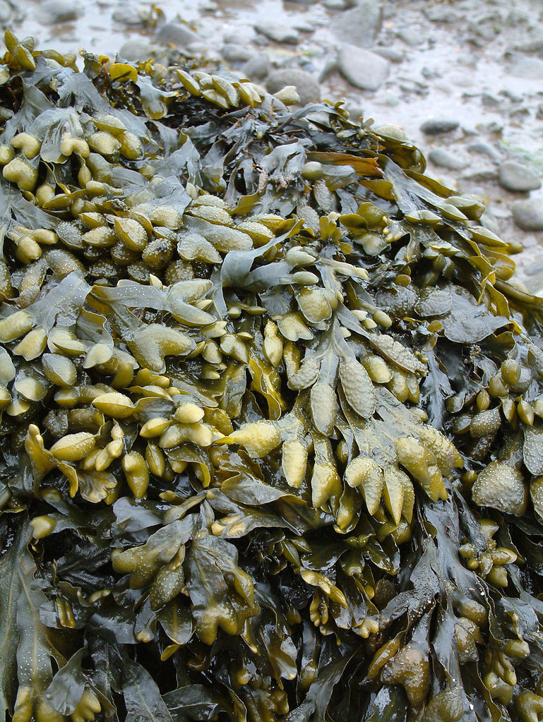

*Fucus vesiculosus*. Alex Lomas, [CC BY 2.0](https://creativecommons.org/licenses/by/2.0)

The paper is [here](https://doi.org/10.1371/journal.pone.0152948)

Al-Janabi, B., Kruse, I., Graiff, A., Winde, V., Lenz, M. & Wahl, M. (2016). Buffering and amplifying interactions among OAW (Ocean Acidification & Warming) and nutrient enrichment on early life-stage *Fucus vesiculosus* L. (Phaeophyceae) and their carry over effects to hypoxia impact. *PLoS One*, 11, e0152948.

### Preliminaries

First, load the required packages (afex, car, lattice, lme4, lmerTest, nlme, VCA, ez, emmeans, Rmisc, MuMIn)

Import aljanabi data file (aljanabi.csv)

```r
aljanabi <- read.csv("../data/aljanabi.csv")
aljanabi
```

| oaw | nutrient | mesocosm | sib | area0 | area1 | meanrate |
| --- | --- | --- | --- | --- | --- | --- |
| OAW- | N- | a | Sibling1 | 0.0110 | 0.0455 | 2.6680 |
| OAW- | N- | b | Sibling1 | 0.0110 | 0.0913 | 4.0009 |
| OAW- | N- | c | Sibling1 | 0.0110 | 0.0776 | 3.6887 |
| OAW- | N- | a | Sibling2 | 0.0087 | 0.0369 | 2.7148 |
| OAW- | N- | b | Sibling2 | 0.0087 | 0.0756 | 4.0870 |
| OAW- | N- | c | Sibling2 | 0.0087 | 0.0610 | 3.6752 |
| OAW- | N- | a | Sibling3 | 0.0136 | 0.0385 | 1.9509 |
| OAW- | N- | b | Sibling3 | 0.0136 | 0.0459 | 2.2847 |
| OAW- | N- | c | Sibling3 | 0.0136 | 0.0562 | 2.6687 |
| OAW- | N- | a | Sibling4 | 0.0100 | 0.0473 | 2.9238 |

[output cut: 182 more lines]

set contrasts from afex

```r
set_sum_contrasts()
```

```
## setting contr.sum globally: options(contrasts=c('contr.sum', 'contr.poly'))
```

## Model fitting

Don’t use OLS ANOVA because of missing cell

Fit mixed effects models with lmer

```r
aljanabi.lmer <- lmer(meanrate~oaw+nutrient+oaw*nutrient+sib+oaw*sib+nutrient*sib+oaw*nutrient*sib+(1|mesocosm), REML=TRUE, na.action=na.omit, aljanabi)
```

Check residuals from lmer plot

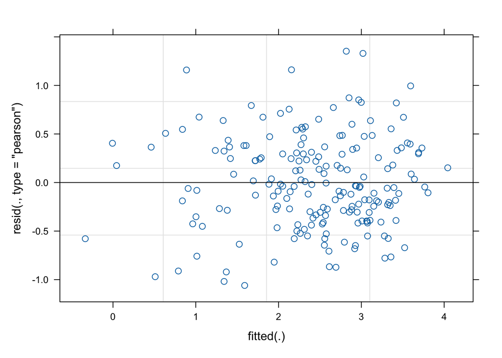

```r
plot(aljanabi.lmer)
```

Looks fine

```r
summary(aljanabi.lmer, ddf="Kenward-Roger")
```

```
## Linear mixed model fit by REML. t-tests use Kenward-Roger's method [
## lmerModLmerTest]
## Formula: meanrate ~ oaw + nutrient + oaw * nutrient + sib + oaw * sib +
##     nutrient * sib + oaw * nutrient * sib + (1 | mesocosm)
##    Data: aljanabi
##
## REML criterion at convergence: 420.3
##
## Scaled residuals:
##      Min       1Q   Median       3Q      Max
## -1.78235 -0.53967 -0.06754  0.55534  2.27385
##
## Random effects:
##  Groups   Name        Variance Std.Dev.
##  mesocosm (Intercept) 0.06653  0.2579
##  Residual             0.35377  0.5948
## Number of obs: 191, groups:  mesocosm, 12
##
## Fixed effects:
##                       Estimate Std. Error        df t value Pr(>|t|)
## (Intercept)            2.43430    0.08603   7.99963  28.295 2.63e-09 ***
## oaw1                   0.48744    0.08603   7.99963   5.666 0.000473 ***
## nutrient1             -0.31572    0.08603   7.99963  -3.670 0.006312 **
## sib1                  -0.01593    0.16629 119.00237  -0.096 0.923860
## sib2                  -0.17518    0.16629 119.00237  -1.053 0.294281
## sib3                  -0.33308    0.16629 119.00237  -2.003 0.047455 *
## sib4                  -0.47234    0.16629 119.00237  -2.840 0.005301 **
## sib5                   0.36989    0.17625 119.42278   2.099 0.037956 *
## sib6                  -0.57029    0.16629 119.00237  -3.429 0.000832 ***
## sib7                  -0.64904    0.16629 119.00237  -3.903 0.000158 ***
## sib8                  -0.11039    0.16629 119.00237  -0.664 0.508071
## sib9                   0.42231    0.16629 119.00237   2.540 0.012387 *
## sib10                 -0.14582    0.16629 119.00237  -0.877 0.382320
## sib11                  0.34078    0.16629 119.00237   2.049 0.042633 *
## sib12                 -0.06305    0.16629 119.00237  -0.379 0.705244
## sib13                  0.03526    0.16629 119.00237   0.212 0.832419
## sib14                  0.74411    0.16629 119.00237   4.475 1.76e-05 ***
## sib15                  0.18688    0.16629 119.00237   1.124 0.263356
## oaw1:nutrient1         0.25402    0.08603   7.99963   2.953 0.018354 *
## oaw1:sib1              0.02257    0.16629 119.00237   0.136 0.892266
```

[output cut: 31 more lines]

```
## oaw1:nutrient1:sib3    0.21914    0.16629 119.00237   1.318 0.190109
## oaw1:nutrient1:sib4   -0.08261    0.16629 119.00237  -0.497 0.620253
## oaw1:nutrient1:sib5   -0.12648    0.17625 119.42278  -0.718 0.474396
## oaw1:nutrient1:sib6   -0.07806    0.16629 119.00237  -0.469 0.639622
## oaw1:nutrient1:sib7    0.39245    0.16629 119.00237   2.360 0.019901 *
## oaw1:nutrient1:sib8    0.09197    0.16629 119.00237   0.553 0.581257
## oaw1:nutrient1:sib9   -0.14914    0.16629 119.00237  -0.897 0.371616
## oaw1:nutrient1:sib10  -0.13999    0.16629 119.00237  -0.842 0.401580
## oaw1:nutrient1:sib11  -0.26137    0.16629 119.00237  -1.572 0.118663
## oaw1:nutrient1:sib12   0.20103    0.16629 119.00237   1.209 0.229104
## oaw1:nutrient1:sib13   0.04545    0.16629 119.00237   0.273 0.785107
## oaw1:nutrient1:sib14  -0.07526    0.16629 119.00237  -0.453 0.651667
## oaw1:nutrient1:sib15   0.15503    0.16629 119.00237   0.932 0.353088
## ---
## Signif. codes:  0 '***' 0.001 '**' 0.01 '*' 0.05 '.' 0.1 ' ' 1
```

```
##
## Correlation matrix not shown by default, as p = 64 > 12.
## Use print(x, correlation=TRUE)  or
##     vcov(x)        if you need it
```

```r
anova(aljanabi.lmer, ddf="Kenward-Roger")
```

|  | Sum Sq | Mean Sq | NumDF | DenDF | F value | Pr(>F) |
| --- | --- | --- | --- | --- | --- | --- |
| oaw | 11.355990 | 11.3559901 | 1 | 7.999633 | 32.1001465 | 4.728253e-04 |
| nutrient | 4.764180 | 4.7641802 | 1 | 7.999633 | 13.4669791 | 6.312367e-03 |
| sib | 28.127553 | 1.8751702 | 15 | 119.028561 | 5.3005714 | 5.024069e-08 |
| oaw:nutrient | 3.084085 | 3.0840848 | 1 | 7.999633 | 8.7178283 | 1.835362e-02 |
| oaw:sib | 4.039879 | 0.2693253 | 15 | 119.028561 | 0.7613058 | 7.172454e-01 |
| nutrient:sib | 6.147433 | 0.4098289 | 15 | 119.028561 | 1.1584693 | 3.137711e-01 |
| oaw:nutrient:sib | 7.711271 | 0.5140848 | 15 | 119.028561 | 1.4531710 | 1.342442e-01 |

Get variance components with CIs

```r
aljanabi.ci <- confint.merMod(aljanabi.lmer,oldNames=FALSE)
```

```
## Computing profile confidence intervals ...
```

```r
aljanabi.vc <- (aljanabi.ci)^2
print(aljanabi.vc)
```

[output not shown]

[output cut: 12 more lines]

```
## oaw1:nutrient1:sib1     8.777533e-03 1.941997e-01
## oaw1:nutrient1:sib2     4.911279e-01 2.770083e-02
## oaw1:nutrient1:sib3     2.309298e-03 2.365016e-01
## oaw1:nutrient1:sib4     1.223636e-01 3.406399e-02
## oaw1:nutrient1:sib5     1.676627e-01 2.456186e-02
## oaw1:nutrient1:sib6     1.192011e-01 3.576423e-02
## oaw1:nutrient1:sib7     1.569045e-02 4.351130e-01
## oaw1:nutrient1:sib8     3.070269e-02 1.289870e-01
## oaw1:nutrient1:sib9     1.733308e-01 1.393328e-02
## oaw1:nutrient1:sib10    1.657957e-01 1.617712e-02
## oaw1:nutrient1:sib11    2.793794e-01 3.370952e-05
## oaw1:nutrient1:sib12    4.377607e-03 2.192168e-01
## oaw1:nutrient1:sib13    4.917165e-02 9.773293e-02
## oaw1:nutrient1:sib14    1.172755e-01 3.683111e-02
## oaw1:nutrient1:sib15    1.258065e-02 1.782579e-01
```